# Analyzing LeBron James’ Career Performance in the Regular Season and Playoffs

## Project Overview

This project analyzes LeBron James’ offensive performance across his career, comparing regular season and playoff statistics. The goal is to identify whether his production changes in high-pressure playoff environments.

## Data & Tools

- Data sourced from compiled season statistics from basketball-reference.com
- Tools used: R, dplyr, tidyr, ggplot2

## Data Preparation

Cleaned and combined datasets to allow direct comparison between regular season and playoff performance.

## Career Performance Overview

### Regular Season Trends

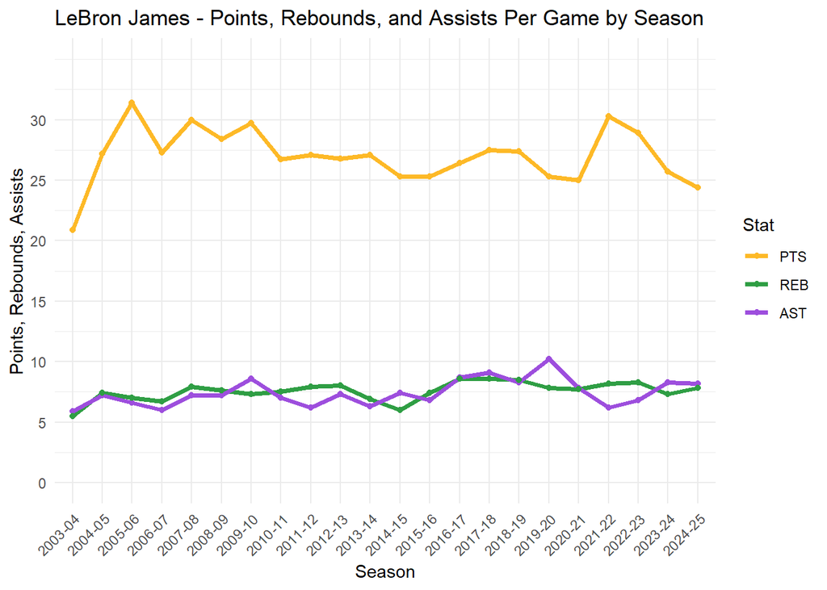

This chart shows LeBron’s points, rebounds, and assists per game across his regular season career. Scoring remains consistently elite, with LeBron averaging 25+ PPG across nearly two decades.Rebounds and assists show a slight gradual increase, but overall consistent overall. This highlights his sustained all-around production and longevity as an elite scorer, playmaker, and rebounder.

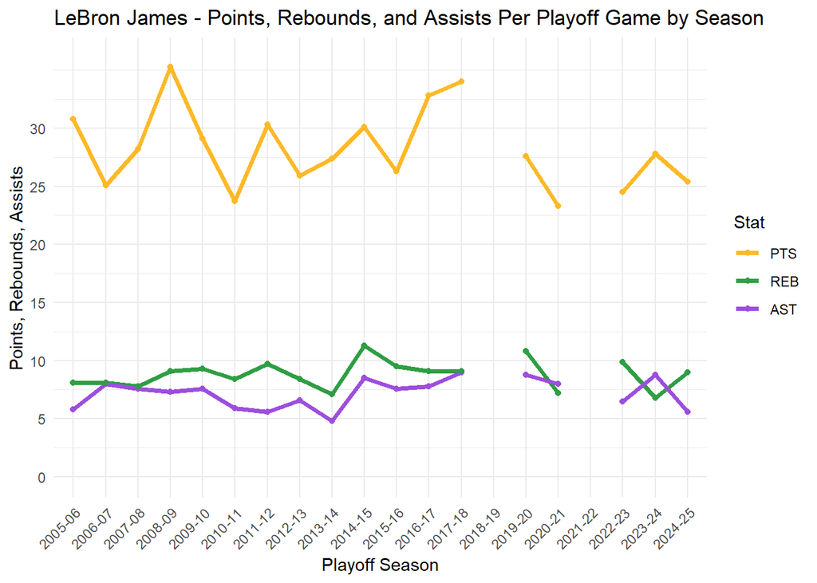

This chart shows LeBron’s points, rebounds, and assists per game across his playoff career. Scoring remains consistently elite, typically ranging between 25–34 PPG across seasons. Rebounds show slight increases in several playoff runs, while assists remain relatively stable overall. This highlights his ability to maintain high-level all-around production in the playoffs, with a particularly notable impact on the glass.

## Metric Comparison

### Points Per Game (PPG)

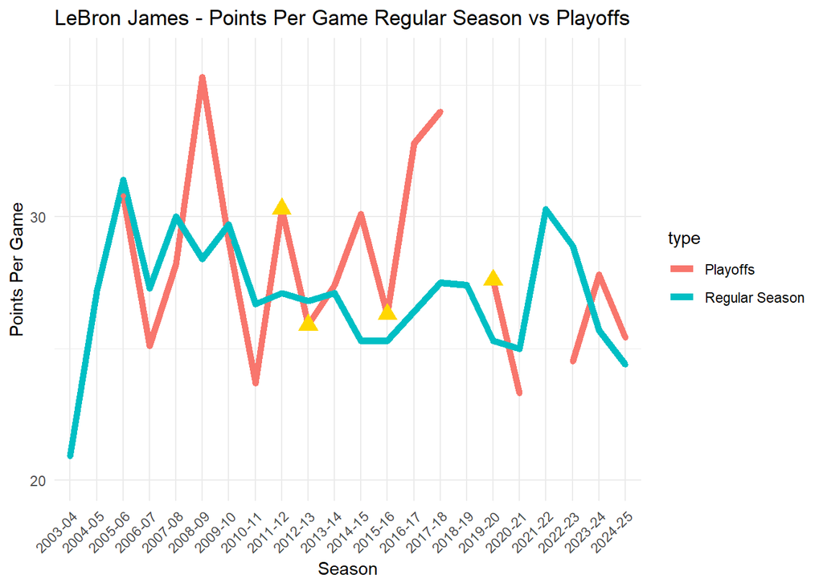

LeBron maintains consistently elite scoring in both the regular season and playoffs, with playoff performance occasionally exceeding regular season output, though differences vary by season without a clear overall trend.

### Assists Per Game (APG)

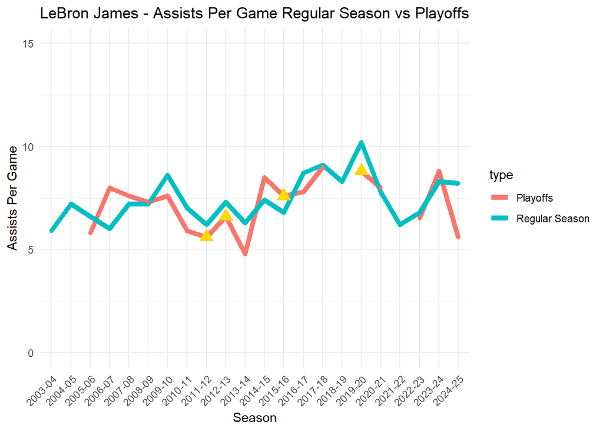

LeBron’s assist production remains relatively consistent between the regular season and playoffs, with minor year-to-year variation and no clear overall trend of increase or decrease.

### Rebounds Per Game (RPG)

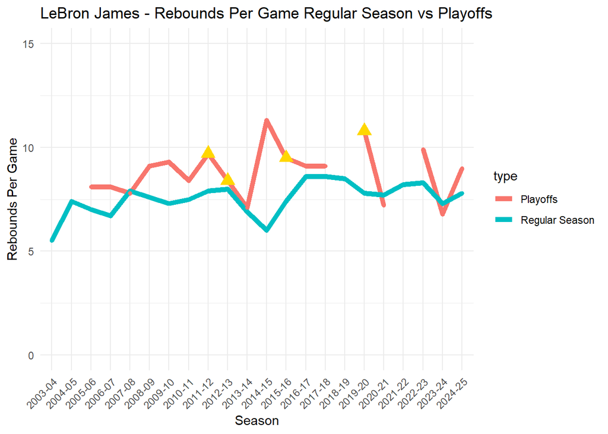

LeBron’s rebounding is consistently higher in the playoffs compared to the regular season, with a clear and noticeable increase across multiple seasons.

## Points, Rebounds, Assists (PRA)

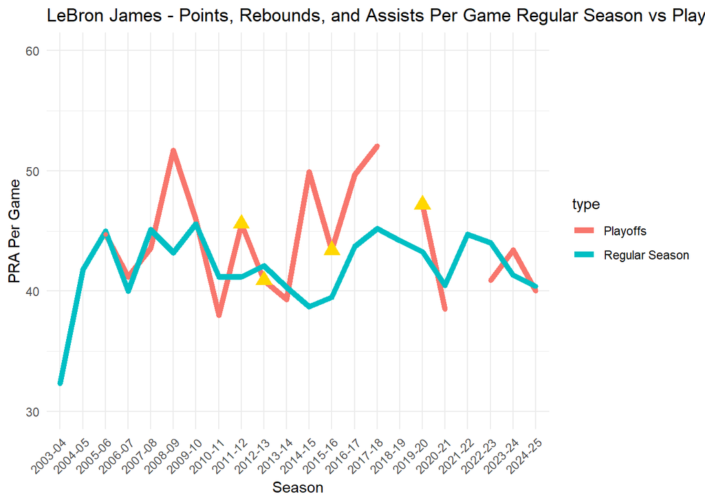

LeBron’s PRA production is comparable between the regular season and playoffs, with fluctuations across seasons but no meaningful overall change.

## Performance Differences

To directly compare playoff and regular season performance, I created a differences data frame by subtracting regular season averages from playoff averages for each season. Positive values indicate better playoff performance, while negative values indicate lower production in the playoffs.

## Average Difference By Metric

On average, LeBron performed better in the playoffs, scoring 1.07 more points and grabbing 1.24 more rebounds. However, his assists decreased slightly by 0.33, while overall production (PRA) increased by 1.99.

## Statistical Testing

To test whether these observed differences were statistically significant, I used paired t-tests comparing LeBron’s regular season and playoff performance across seasons.

### Points Paired T-test

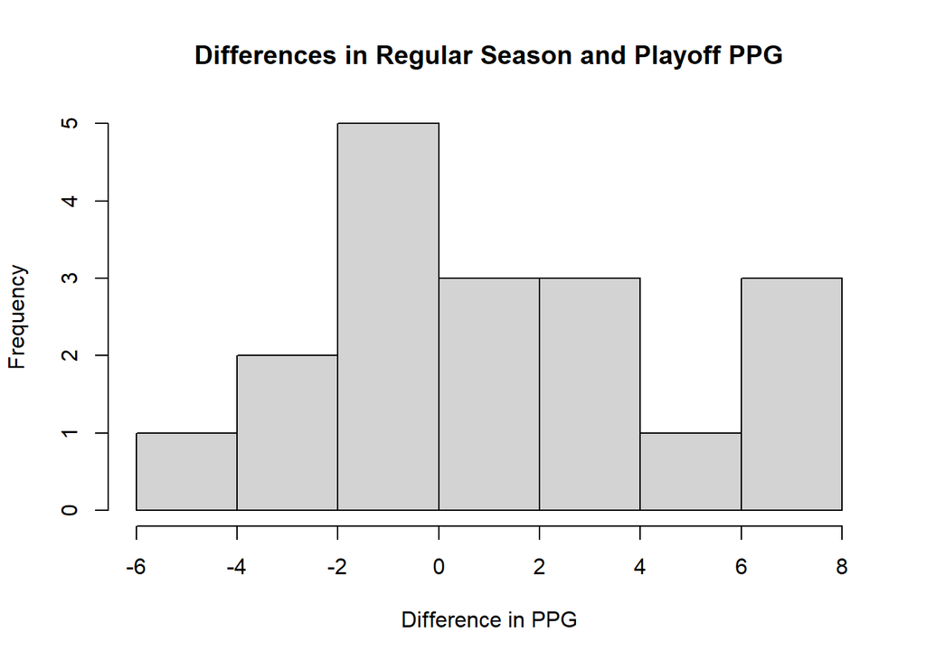

**Points Interpretation:**

On average, LeBron James scores approximately 1.07 more points per game in the playoffs compared to the regular season. However, a paired t-test indicates that this difference is not statistically significant (t = 1.34, p = 0.198), indicating the increase is not consistent across seasons.

### Rebounds Paired T-test

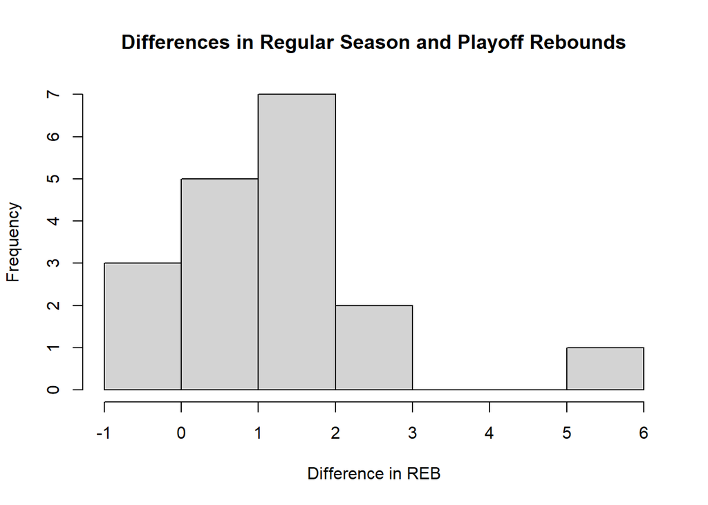

**Rebounds Interpretation:**

In contrast, LeBron averages 1.24 more rebounds per game in the playoffs than in the regular season. This difference is statistically significant (t = 3.83, p = 0.001), indicating a consistent increase in rebounding performance during postseason play.

### Assists Paired T-test

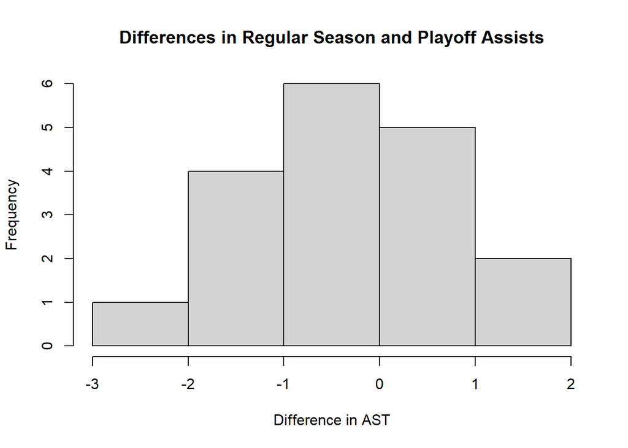

**Assists Interpretation:**

LeBron averages 0.33 fewer assists per game in the playoffs compared to the regular season. This difference is not statistically significant (t = -1.28, p = 0.217), suggesting no consistent change in playmaking output.

### PRA Paired T-test

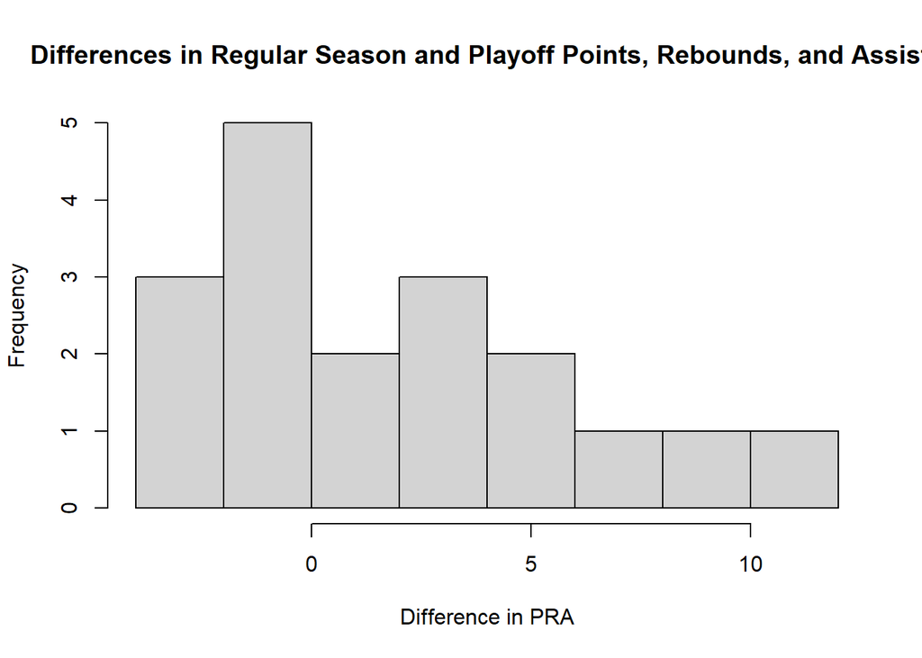

**Points, Rebounds, Assists (PRA) Interpretation:**

Overall, LeBron averages 1.99 more combined points, rebounds, and assists (PRA) in the playoffs. However, this difference is not statistically significant (t = 2.03, p = 0.0587), barely missing the conventional significance threshold of α = 0.05.

## Key Findings

Overall, the analysis shows that LeBron’s performance remains largely consistent between the regular season and playoffs. While scoring, assists, and overall PRA do not show statistically significant changes, rebounding demonstrates a clear and consistent increase in the postseason. This suggests that while LeBron maintains a high level of performance year-round, he contributes additional impact in rebounding during playoff competition.

- **Scoring (PPG):** Increased slightly in the playoffs, but not statistically significant.
- **Rebounding (RPG):** Increased in the playoffs and was statistically significant, indicating a consistent boost in rebounding impact.
- **Assists (APG):** Decreased slightly in the playoffs, but not statistically significant.
- **Overall Offensive Production (PRA):** Increased modestly, but did not reach statistical significance.

## Limitations

While this analysis provides useful insights, several limitations should be considered:

- Data Set required manual cleaning and adjustments, which may introduce minor inconsistencies.
- The analysis uses a relatively small sample size (~20 seasons), limiting statistical power.
- Only used basic box score metrics (points, rebounds, assists)
- Contextual factors such as team composition, opponent strength, and role changes were not considered

## Future Work

There are several opportunities to expand and improve this analysis:

- Incorporate advanced metrics such as true shooting percentage, usage rate, effective field goal percentage, or player efficiency rating.
- Compare LeBron’s playoff performance to other all-time great players to provide broader context.
- Analyze individual playoff runs at the series level.
- Build an interactive dashboard to allow users to explore performance trends dynamically.